# 400_Lab3

Chuan Du (Sophie)

12/3/2018

#### Problem 1

##### Part a

**Answer:** The purpose of doing Markov Chain Monte Carlo (MCMC) is to obtain sample points from complex distribution that is difficult to sample from directly. By constructing a Markov Chain whose stationary distribution is exactly equal to our target distribution, we use MCMC to generate random samples from the target distribution.

##### Part b

**Answer:** The Metropolis Algorithm is a special case of the Metropolis Hashings Algorithm. In the Metropolis Algorithm, the proposal distribution $q(.|.)$ has to be symmetric where $q(\theta_1 | \theta_2) = q(\theta_2 | \theta_1)$, while in the Metropolis Hashings Algorithm, $q(.|.)$ does not have to be symmetric.

##### Part c

**Answer:** The purpose of both Ridge regression and LASSO regression is to avoid multicollinarity, too many predictors and ill-conditioned $X^T X$. Both of them add shrinkage penalty to shrink the coefficients toward 0. LASSO regression also helps with variable selection (reduces variables).

##### Part d

**Answer:** The Independence of irrelevant alternatives (IIA) assumption for Multinomial Logit discrete choice model is that the ratio of the probabilities of choosing two alternatives is independent of the presence or attributes of any other alternative.

#### Problem 2

```r
#load data
gas = read.csv("gas_mileage.csv", header = T); head(gas, 5)
```

```
##     Mpg Displacement Hpower Torque Comp_ratio Rear_axle_ratio Carb_barrels
## 1 18.90          350    165    260       8.00            2.56            4
## 2 17.00          350    170    275       8.50            2.56            4
## 3 20.00          250    105    185       8.25            2.73            1
## 4 18.25          351    143    255       8.00            3.00            2
## 5 20.07          225     95    170       8.40            2.76            1
##   No._speeds Length Width Weight Trans._type
## 1          3  200.3  69.9   3910           1
## 2          3  199.6  72.9   3860           1
## 3          3  196.7  72.2   3510           1
## 4          3  199.9  74.0   3890           1
## 5          3  194.1  71.8   3365           0
```

##### Part a

```r
library(quantreg)
#fit quantile regression model
fit1 = rq(Mpg ~ ., tau = seq(0.05, 0.95, by = 0.05), data = gas)
summary(fit1)
```

```
##
## Call: rq(formula = Mpg ~ ., tau = seq(0.05, 0.95, by = 0.05), data = gas)
##
## tau: [1] 0.05
##
## Coefficients:
##                 coefficients   lower bd       upper bd
## (Intercept)       7.505845e+01 -1.797693e+308  1.797693e+308
## Displacement     -3.701000e-02 -1.797693e+308  1.797693e+308
## Hpower           -1.893800e-01 -1.797693e+308  1.797693e+308
## Torque            1.094900e-01 -1.797693e+308  1.797693e+308
## Comp_ratio       -3.509360e+00 -1.797693e+308  1.797693e+308
## Rear_axle_ratio   3.866260e+00 -1.797693e+308  1.797693e+308
## Carb_barrels      2.145330e+00 -1.797693e+308  1.797693e+308
## No._speeds       -2.299040e+00 -1.797693e+308  1.797693e+308
## Length            1.753600e-01 -1.797693e+308  1.797693e+308
## Width            -6.623400e-01 -1.797693e+308  1.797693e+308
## Weight           -3.030000e-03 -1.797693e+308  1.797693e+308
## Trans._type      -9.004500e-01  -1.792682e+01  1.797693e+308
##
## Call: rq(formula = Mpg ~ ., tau = seq(0.05, 0.95, by = 0.05), data = gas)
##
## tau: [1] 0.1
##
## Coefficients:
##                 coefficients   lower bd       upper bd
## (Intercept)       7.505845e+01  -2.640074e+02   1.965771e+02
## Displacement     -3.701000e-02  -3.574400e-01   6.540000e-02
## Hpower           -1.893800e-01  -7.592400e-01   1.053380e+00
## Torque            1.094900e-01  -3.856000e-01   8.116000e-01
## Comp_ratio       -3.509360e+00  -1.141334e+01   7.802265e+01
## Rear_axle_ratio   3.866260e+00  -1.949856e+01   3.144942e+01
## Carb_barrels      2.145330e+00  -1.083878e+01   1.214711e+01
## No._speeds       -2.299040e+00  -9.998130e+00   1.812914e+01
## Length            1.753600e-01  -2.232600e-01  1.797693e+308
## Width            -6.623400e-01 -1.797693e+308   1.918620e+00
## Weight           -3.030000e-03  -1.060100e-01   1.284000e-02
## Trans._type      -9.004500e-01  -1.561480e+00  1.797693e+308
##
## Call: rq(formula = Mpg ~ ., tau = seq(0.05, 0.95, by = 0.05), data = gas)
```

[output cut: 306 more lines]

```
##
## Coefficients:
##                 coefficients   lower bd       upper bd
## (Intercept)       6.690518e+01 -1.797693e+308  1.797693e+308
## Displacement     -1.753400e-01 -1.797693e+308  1.797693e+308
## Hpower           -7.653000e-02 -1.797693e+308  1.797693e+308
## Torque            2.567900e-01 -1.797693e+308  1.797693e+308
## Comp_ratio        9.785700e-01 -1.797693e+308  1.797693e+308
## Rear_axle_ratio   1.973560e+00 -1.797693e+308  1.797693e+308
## Carb_barrels      1.741000e-02 -1.797693e+308  1.797693e+308
## No._speeds       -4.769530e+00 -1.797693e+308  1.797693e+308
## Length            1.180000e-03 -1.797693e+308  1.797693e+308
## Width            -4.858100e-01 -1.797693e+308  1.797693e+308
## Weight            1.210000e-03 -1.797693e+308  1.797693e+308
## Trans._type      -1.012671e+01 -1.797693e+308   7.544440e+00
```

##### Part b

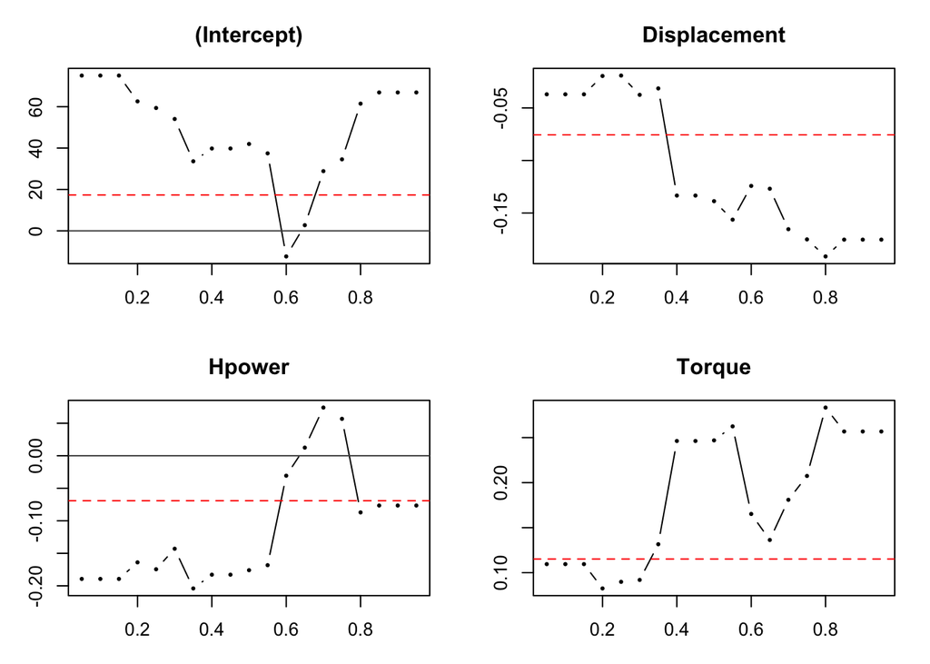

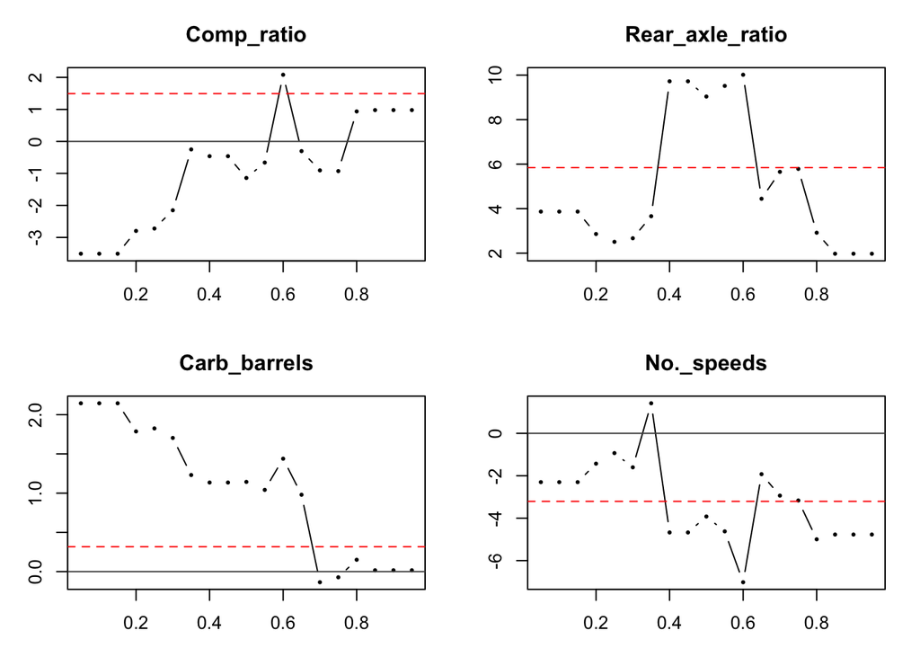

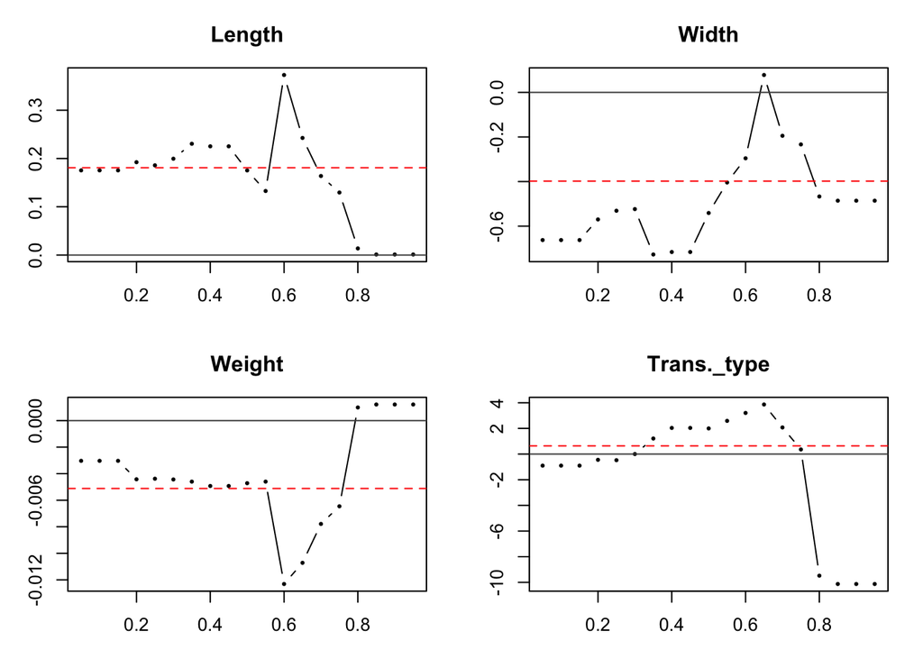

```r
plot(fit1, mfrow = c(2, 2))
```

##### Part c

**Answer:**

1. Hpower: in lower quantiles (0.05th to around 0.57th), a unit increase in displacement will lead to 0.2 unit decrease in Mpg, while in middle - upper quantiles (around 0.65th to 0.77th), a unit increase in displacement will lead to an increase in Mpg.
2. Carb_barrels: in quantiles 0.05th to around 0.69th, a unit increase in carb_barrels will lead to an increase in Mpg, while in quantiles 0.7th to 0.76th, a unit increase in crab_barrels will lead to decrease in Mpg, and in upper quantiles (around 0.78th to 0.95th), a unit increase in carb_barrels will lead to no change in Mpg.
3. Weight: in lower quantiles (0.05th to around 0.79th), a unit increase in weight will lead to an decrease in Mpg, while in upper quantiles (0.8th to 0.95th), a unit increase in weight will lead to an increase in Mpg, though the change is slight.

##### Part d

```r
#use bootstrap for se of regression coeffs for conditional median
fit1_median = rq(Mpg ~ ., tau = 0.5, data = gas)
summary(fit1_median, se = "boot")
```

```
##
## Call: rq(formula = Mpg ~ ., tau = 0.5, data = gas)
##
## tau: [1] 0.5
##
## Coefficients:
##                 Value    Std. Error t value  Pr(>|t|)
## (Intercept)     41.98707 52.43156    0.80080  0.43369
## Displacement    -0.13873  0.10558   -1.31403  0.20534
## Hpower          -0.17596  0.19476   -0.90344  0.37822
## Torque           0.24692  0.17312    1.42634  0.17089
## Comp_ratio      -1.14223  5.08624   -0.22457  0.82484
## Rear_axle_ratio  9.03682  6.73399    1.34197  0.19629
## Carb_barrels     1.14349  2.51172    0.45526  0.65436
## No._speeds      -3.91968  7.74727   -0.50594  0.61904
## Length           0.17526  0.33036    0.53053  0.60223
## Width           -0.54095  0.67705   -0.79898  0.43472
## Weight          -0.00472  0.00999   -0.47218  0.64247
## Trans._type      1.99845  8.44051    0.23677  0.81551
```

#### Problem 3

```r
#load data
car = read.csv("car.csv", header = TRUE); head(car, 5)
```

```
##   y income car_age
## 1 0     32       3
## 2 0     45       2
## 3 1     60       2
## 4 0     53       1
## 5 0     25       4
```

##### Part a

```r
library(e1071)
```

```r
fit2 = svm(factor(y) ~ ., data = car)
summary(fit2)
```

```
##
## Call:
## svm(formula = factor(y) ~ ., data = car)
##
##
## Parameters:
##    SVM-Type:  C-classification
##  SVM-Kernel:  radial
##        cost:  1
##       gamma:  0.5
##
## Number of Support Vectors:  27
##
##  ( 14 13 )
##
##
## Number of Classes:  2
##
## Levels:
##  0 1
```

##### Part b

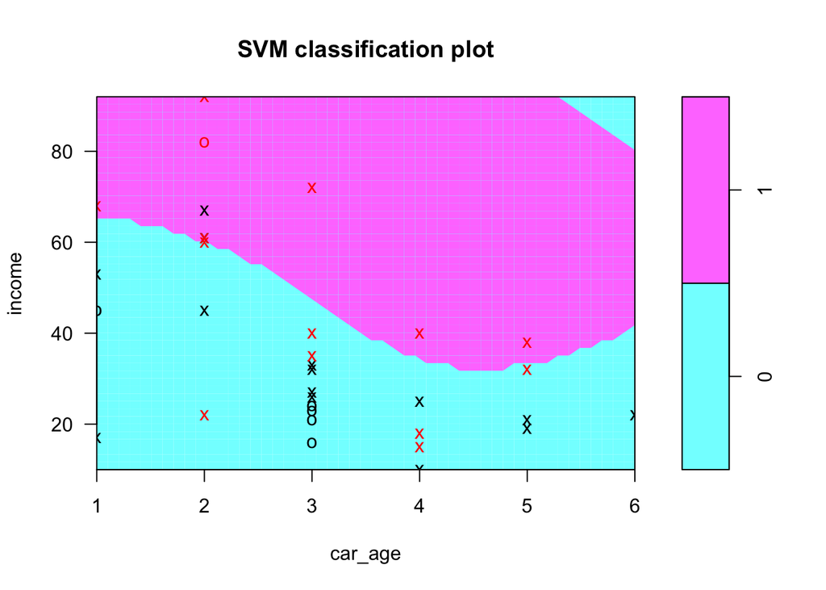

```r
plot(fit2, data = car, income ~ car_age) #from income to car_age
```

##### Part c

```r
#create new data
new_obs = with(car, data.frame(income = 50, car_age = 5))
#predict response
new_obs$class = predict(fit2, new_obs, type = "response"); new_obs
```

```
##   income car_age class
## 1     50       5     1
```

**Answer:** Based on the prediction result shown above, we could see that the person with income = 50 and car_age = 5 has response = 1, i.e. this person will buy the car.